# Storing Spatial Transcriptomics Results

Ally Hawkins for CCDL

In this notebook we are doing a quick exploration of the use of storing spatial data in a [`SpatialExperiment` object](https://bioconductor.org/packages/release/bioc/vignettes/SpatialExperiment/inst/doc/SpatialExperiment.html#3_Common_operations) or in a [`Seurat` object](https://satijalab.org/seurat/articles/spatial_vignette.html). We will take a look at one library, SCPCR000372, that has been quantified with Spaceranger and compare the use of `SpatialExperiment` to `Seurat`.

## Set Up

```r
library(magrittr)
library(ggplot2)
library(SingleCellExperiment)
library(SpatialExperiment)
```

```
Found more than one class "SpatialImage" in cache; using the first, from namespace 'SpatialExperiment'
Also defined by ‘SeuratObject’
```

```r
# load in benchmarking functions that will be used for copying data and generating sample tables
function_path <- file.path(".." ,"benchmarking-functions", "R")
file.path(function_path, list.files(function_path, pattern = "*.R$")) %>%
  purrr::walk(source)
```

```r
# set up file paths
base_dir <- here::here()

# output folder to store alevin-fry and spaceranger quants from S3
data_dir <- file.path(base_dir, "data", "spatial")
s3_out <- file.path(data_dir, "data", "quants")

# results directory
results_dir <- file.path(data_dir, "results")

# create directories
if(!dir.exists(data_dir)){
  dir.create(data_dir, recursive = TRUE)
}

if(!dir.exists(results_dir)){
  dir.create(results_dir, recursive = TRUE)
}
```

```r
mito_file <- file.path(base_dir, "sample-info", "Homo_sapiens.GRCh38.103.mitogenes.txt")

# read in mito genes
mito_genes <- readr::read_tsv(mito_file, col_names = "gene_id")
mito_genes <- mito_genes %>%
  dplyr::pull(gene_id) %>%
  unique()
```

## Copy data from S3

```r
# set samples to process
sample_id <- c("SCPCR000372")
```

```r
# download alevin fry and cellranger output
aws_copy_samples(local_dir = s3_out,
                 s3_dir = "s3://nextflow-ccdl-results/scpca",
                 samples = sample_id,
                 tools = c("alevin-fry-knee", "cellranger"))
```

## Comparing SpatialExperiment to Seurat

### Importing Alevin-fry and Spaceranger output into a SpatialExperiment

First we are testing use of a `SpatialExperiment` object to store the spatial transcriptomics results. We will look at the Alevin-fry + Spaceranger quantification and use a custom function to create the combined object from both tools.

```r
# get path to fry output directory
fry_dir <- file.path(s3_out, "alevin-fry-knee", sample_id)
fry_dir <- paste0(fry_dir, "-spliced_intron_txome_k31-salign-cr-like-em-knee")

# paths to spatial folders
cellranger_folder <- paste0(sample_id, "-cdna-spatial")
spatial_dir <- file.path(s3_out, "cellranger", cellranger_folder, "outs", "spatial")
```

```r
# read in combined fry and spaceranger spe
fry_spe <- create_fry_spaceranger_spe(fry_dir,
                                       spatial_dir,
                                       sample_id)
```

```
Found more than one class "SpatialImage" in cache; using the first, from namespace 'SpatialExperiment'
Also defined by ‘SeuratObject’
```

### Importing as Seurat Object

Below we will import the same data but as a `Seurat` object instead of a `SpatialExperiment` object.

```r
# first create sce from Alevin output
fry_sce <- scpcaTools::read_alevin(fry_dir,
                                   usa_mode = TRUE,
                                   which_counts = "spliced")

# convert sce to seurat object
fry_seurat <- Seurat::CreateSeuratObject(counts = counts(fry_sce),
                                 project = "SPATIAL",
                                 assay = "Spatial")

# read in image data using Seurat and subset to common cells
image_data <- Seurat::Read10X_Image(spatial_dir)
rownames(image_data@coordinates) <- gsub("-1","", rownames(image_data@coordinates))
common_cells <- intersect(Seurat::Cells(x = fry_seurat), rownames(image_data@coordinates))
image_data <- image_data[common_cells,]

# add image data to Seurat
Seurat::DefaultAssay(object = image_data) <- "Spatial"
fry_seurat[['slice']] <- image_data
```

### Comparing Seurat and Spatial Experiment

Now let’s take a look at how each of these objects stores information for the experiment.

```r
head(colData(fry_spe))
```

```
DataFrame with 6 rows and 1 column
                   sample_id
                 <character>
TGGCGATCAAGTTATG SCPCR000372
GCAGGACTATAGAATA SCPCR000372
CCATCGCAGTTAAACT SCPCR000372
TAGCTCGCCTGATAAC SCPCR000372
GATAGGTAACGTTGAC SCPCR000372
GGGAGTAATGGCTGGC SCPCR000372
```

```r
head(fry_seurat@meta.data)
```

|  | orig.ident | nCount_Spatial | nFeature_Spatial |
| --- | --- | --- | --- |
| TGGCGATCAAGTTATG | SPATIAL | 16606.12 | 5342 |
| GCAGGACTATAGAATA | SPATIAL | 16574.81 | 5812 |
| CCATCGCAGTTAAACT | SPATIAL | 16978.88 | 5806 |
| TAGCTCGCCTGATAAC | SPATIAL | 16631.08 | 5669 |
| GATAGGTAACGTTGAC | SPATIAL | 17316.32 | 5830 |
| GGGAGTAATGGCTGGC | SPATIAL | 15565.13 | 5192 |

Seurat automatically adds some per cell QC metrics here, but in general the `colData` looks similar to what we would expect for a `SingleCellExperiment` for the `SpatialExperiment`.

```r
head(rowData(fry_spe))
```

```
DataFrame with 6 rows and 0 columns
```

```r
head(fry_seurat[["Spatial"]]@meta.features)
```

| ENSG00000000003 |
| --- |
| ENSG00000000005 |
| ENSG00000000419 |
| ENSG00000000457 |
| ENSG00000000460 |
| ENSG00000000938 |

It looks like both of these start off with no `rowData` as expected.

```r
fry_spe <- fry_spe %>%
  scuttle::addPerCellQCMetrics(subsets = list(mito_genes = mito_genes[mito_genes %in% rownames(fry_spe)]))
```

```
Found more than one class "SpatialImage" in cache; using the first, from namespace 'SpatialExperiment'
Also defined by ‘SeuratObject’
Found more than one class "SpatialImage" in cache; using the first, from namespace 'SpatialExperiment'
Also defined by ‘SeuratObject’
```

```r
head(colData(fry_spe))
```

```
DataFrame with 6 rows and 7 columns
                   sample_id       sum  detected subsets_mito_genes_sum
                 <character> <numeric> <integer>              <numeric>
TGGCGATCAAGTTATG SCPCR000372   16606.1      5342                240.298
GCAGGACTATAGAATA SCPCR000372   16574.8      5812                225.685
CCATCGCAGTTAAACT SCPCR000372   16978.9      5806                450.882
TAGCTCGCCTGATAAC SCPCR000372   16631.1      5669                334.209
GATAGGTAACGTTGAC SCPCR000372   17316.3      5830                265.890
GGGAGTAATGGCTGGC SCPCR000372   15565.1      5192                393.000
                 subsets_mito_genes_detected subsets_mito_genes_percent     total
                                   <integer>                  <numeric> <numeric>
TGGCGATCAAGTTATG                          12                    1.44705   16606.1
GCAGGACTATAGAATA                          12                    1.36162   16574.8
CCATCGCAGTTAAACT                          12                    2.65555   16978.9
TAGCTCGCCTGATAAC                          11                    2.00954   16631.1
GATAGGTAACGTTGAC                          11                    1.53549   17316.3
GGGAGTAATGGCTGGC                          12                    2.52487   15565.1
```

You can still use the same functions to add in per cell metrics that we are using in `scpcaTools` now on a `SpatialExperiment`.

Let’s specifically look at how each of them stores the data related to the spatial information. The `SpatialExperiment` has three places where it stores spatial information, `spatialData`, `spatialCoords`, and `imgData`.

```r
head(spatialData(fry_spe))
```

```
DataFrame with 6 rows and 4 columns
           barcode in_tissue array_row array_col
       <character> <numeric> <numeric> <numeric>
1 TGGCGATCAAGTTATG         1        51        55
2 GCAGGACTATAGAATA         1        35        37
3 CCATCGCAGTTAAACT         1        50        62
4 TAGCTCGCCTGATAAC         1        50        58
5 GATAGGTAACGTTGAC         1        48        60
6 GGGAGTAATGGCTGGC         1        10        42
```

```r
head(spatialCoords(fry_spe))
```

```
     pxl_col_in_fullres pxl_row_in_fullres
[1,]               4426               6160
[2,]               3441               4659
[3,]               4805               6063
[4,]               4588               6064
[5,]               4695               5875
[6,]               3695               2302
```

`spatialData` holds information about whether or not each barcode was covered by tissue and spatial metadata. `spatialCoords` holds the coordinates for each spot. Although it appears that `spatialData` may be disappearing in a future version of this packag, see [issue #84](https://github.com/drighelli/SpatialExperiment/issues/84).

This same information can be found by looking in the `images` slot in the `Seurat` object.

```r
head(fry_seurat@images)
```

[output not shown]

[output cut: 114 more lines]

```
[1] 0.2

$fiducial
[1] 113.7005

$hires
[1] 0.2

$lowres
[1] 0.06

attr(,"class")
[1] "scalefactors"

Slot "coordinates":
```

|  | tissue | row | col | imagerow | imagecol |
| --- | --- | --- | --- | --- | --- |
| TGGCGATCAAGTTATG | 1 | 51 | 55 | 6160 | 4426 |
| GCAGGACTATAGAATA | 1 | 35 | 37 | 4659 | 3441 |
| CCATCGCAGTTAAACT | 1 | 50 | 62 | 6063 | 4805 |
| TAGCTCGCCTGATAAC | 1 | 50 | 58 | 6064 | 4588 |
| GATAGGTAACGTTGAC | 1 | 48 | 60 | 5875 | 4695 |
| GGGAGTAATGGCTGGC | 1 | 10 | 42 | 2302 | 3695 |
| AGTATAATACTAGGCA | 1 | 25 | 33 | 3719 | 3218 |
| CGTTCAAGGAAACGGA | 1 | 70 | 46 | 7953 | 3952 |
| CCACCCAAGGAAAGTG | 1 | 37 | 75 | 4833 | 5500 |
| ACGTTCGTTCAGGAAA | 1 | 60 | 44 | 7012 | 3837 |

[output cut: 990 more lines]

```
Slot "spot.radius":
[1] 0.01137005

Slot "assay":
[1] "Spatial"

Slot "key":
[1] "slice_"
```

`imgData` holds information about each image that is stored as multiple slices of an image can be stored within one `SpatialExperiment`.

```r
imgData(fry_spe)
```

```
DataFrame with 1 row and 4 columns
    sample_id    image_id   data scaleFactor
  <character> <character> <list>   <numeric>
1 SCPCR000372      lowres   ####        0.06
```

This same information can be found by looking at the `images` slot in the `Seurat` object.

```r
fry_seurat@images$slice@scale.factors
```

```
$spot
[1] 0.2

$fiducial
[1] 113.7005

$hires
[1] 0.2

$lowres
[1] 0.06

attr(,"class")
[1] "scalefactors"
```

Let’s take a look at some example plots that can be produced with each of these objects.

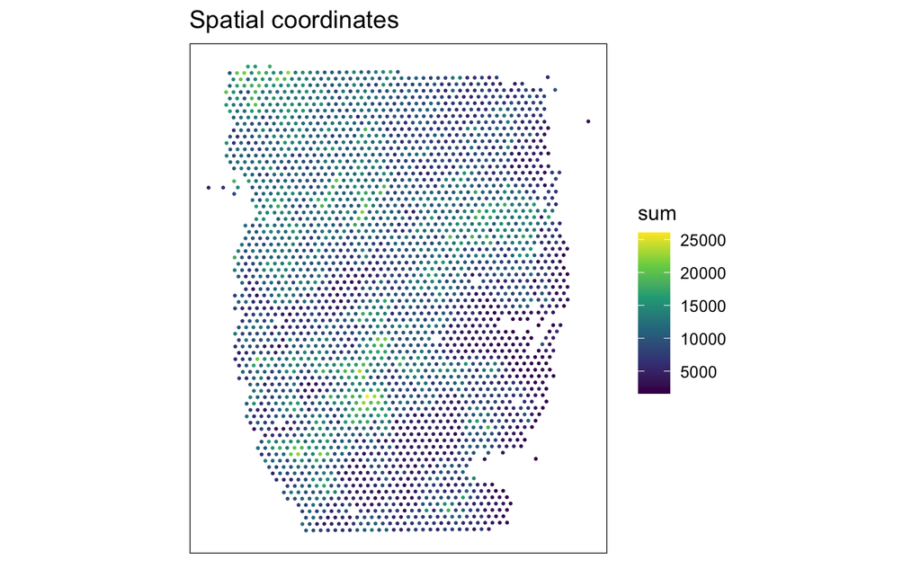

```r
library(viridis)
# plot tissue spots coloring by total UMI count
ggspavis::plotSpots(spe = fry_spe,
          x_coord = "pxl_col_in_fullres",
          y_coord = "pxl_row_in_fullres",
          annotate = "sum") +
  scale_color_viridis_c()
```

You can also overlay the image by using `plotVisium`.

```
Found more than one class "SpatialImage" in cache; using the first, from namespace 'SpatialExperiment'
Also defined by ‘SeuratObject’
Found more than one class "SpatialImage" in cache; using the first, from namespace 'SpatialExperiment'
Also defined by ‘SeuratObject’
```

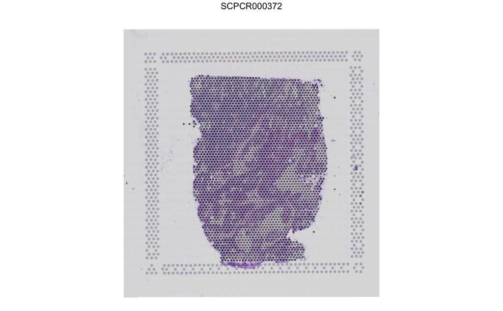

```r
ggspavis::plotVisium(spe = fry_spe[,spatialData(fry_spe)$in_tissue == 1],
                     x_coord = "pxl_col_in_fullres",
                     y_coord = "pxl_row_in_fullres")
```

```r
Seurat::SpatialFeaturePlot(fry_seurat, features = "nCount_Spatial")
```

It looks like overall they both would work and that the `SpatialExperiment` will provide similar functionality to how we have things already set up for single-cell experiments.

One thing to note is that there is incompatibility between `SpatialExperiment` and `Seurat`, and this notebook will not run to completion because of this. The last chunk which includes making the plot using `Seurat` has a conflict with the `imgRaster` function present in both `Seurat` and `SpatialExperiment` that will cause this chunk to fail. Because of this we have run this separately and stored the image separately in `plots/seurat-spatial-plot-example.png`. The way to remove this error is to uninstall the `SpatialExperiment` package and then reinstall `Seurat`. This is documented in [an issue on the `Seurat` repo](https://github.com/satijalab/seurat/issues/5128).